# Relatório de análise de dados - Projetos de carbono e mineração

## Projetos de carbono em áreas de mineração

Tabela 1: Total de créditos de carbono comercializados por projeto

| id_projeto | nome_projeto | vcu_quantity |
| --- | --- | --- |
| 875 | FLORESTAL SANTA MARIA PROJECT | 8 239 076 |
| 977 | RMDLT Portel-Para REDD Project | 6 835 084 |
| 2252 | Rio Anapu-Pacaja REDD Project | 6 307 759 |
| 832 | CIKEL BRAZILIAN AMAZON REDD APD PROJECT – AVOIDING PLANNED DEFORESTATION | 2 894 810 |
| 2508 | UNITOR REDD+ Project | 2 314 892 |
| 1115 | Jari/Amapá REDD+ Project | 2 097 201 |
| 2878 | Rio Madeira Grouped REDD+ Project | 1 752 414 |
| 2551 | Brazilian Amazon APD Grouped Project | 1 380 858 |
| 1503 | RESEX Rio Preto-Jacundá REDD+ Project | 1 363 327 |
| 1654 | Fortaleza Ituxi REDD Project | 1 255 055 |
| 1571 | Projeto REDD+ Manoa | 1 021 576 |
| 1953 | The ARC REDD+ Project | 941 618 |
| 1811 | Jari/Pará REDD+ Project | 900 752 |
| 2558 | ABC Norte REDD Project | 787 063 |
| 2539 | Evergreen REDD+ Project | 766 356 |
| 1329 | Maísa REDD+ Project | 634 948 |
| 1118 | Suruí Forest Carbon Project | 251 529 |
| 2566 | The Serra do Amolar REDD+ Project | 233 704 |
| 1147 | Amazon Rio REDD+ APD Project | 182 347 |
| 2373 | Yellow Ipê Grouped REDD Project | 16 772 |
| Total | - | 40 177 141 |

Tabela 2: Créditos comercializados (sem Eco) em projetos sem áreas de mineração

| id_projeto | resourceName | quantity | vcu_quantity |
| --- | --- | --- | --- |
| 981 | Pacajai REDD+ Project | 9683019 | 9 683 019 |
| 1382 | The Envira Amazonia Project - A Tropical Forest Conservation Project in Acre, Brazil | 7733750 | 7 733 750 |
| 1686 | Agrocortex REDD Project | 2692244 | 2 692 244 |
| 1094 | Ecomapua Amazon REDD Project | 1816290 | 1 816 290 |
| 1112 | The Russas Project | 1407657 | 1 407 657 |
| 1113 | The Valparaiso Project | 1323691 | 1 323 691 |
| 963 | The Purus Project | 861351 | 861 351 |
| 3002 | Hiwi REDD+ Project | 151373 | 151 373 |
| Total | - | 25669375 | 25 669 375 |

Tabela 3: Comparação de créditos comercializados (sem Eco)

|  | Créditos | % |
| --- | --- | --- |
| com_mineracao | 40 177 141 | 61% |
| sem_mineracao | 25 669 375 | 39% |
| Total | 65 846 516 | 100% |

Tabela 4: Quem comprou créditos de projetos em áreas de mineração

| vcu_retirementBeneficiary | vcu_quantity |
| --- | --- |
| NA | 29 140 965 |
| Takeda Pharmaceutical Company | 1 500 000 |
| MOSS EARTH - RETIREMENT FOR TOKENIZATION | 514 939 |
| NATURA COSMÉTICOS S.A. | 433 777 |
| Companhia de Navegação Norsul | 348 914 |
| WEX Europe Services | 306 645 |
| The Boeing Company | 238 898 |
| BV - Banco Votorantim S.A. | 200 000 |
| Telefônica Brasil S.A. | 167 064 |
| Groupe Air France | 166 667 |

Alguns desses créditos constam como *cancelados* (e não *retired*). Precisamos entender melhor a diferença entre os dois. Considerando essas informações, o panorama muda (Tabela 5):

Tabela 5: Créditos cancelados por projeto

| id_projeto | nome_projeto | cancelado_TRUE | cancelado_FALSE |
| --- | --- | --- | --- |
| 977 | RMDLT Portel-Para REDD Project | 6 233 677 | 601 407 |
| 875 | FLORESTAL SANTA MARIA PROJECT | 4 677 402 | 3 561 674 |
| 2878 | Rio Madeira Grouped REDD+ Project | 1 669 954 | 82 460 |
| 1115 | Jari/Amapá REDD+ Project | 1 638 050 | 459 151 |
| 832 | CIKEL BRAZILIAN AMAZON REDD APD PROJECT – AVOIDING PLANNED DEFORESTATION | 1 589 497 | 1 305 313 |
| 1503 | RESEX Rio Preto-Jacundá REDD+ Project | 1 346 827 | 16 500 |
| 1654 | Fortaleza Ituxi REDD Project | 1 151 553 | 103 502 |
| 2508 | UNITOR REDD+ Project | 1 002 053 | 1 312 839 |
| 2252 | Rio Anapu-Pacaja REDD Project | 990 528 | 5 317 231 |
| 1811 | Jari/Pará REDD+ Project | 887 156 | 13 596 |
| 2551 | Brazilian Amazon APD Grouped Project | 875 881 | 504 977 |
| 1329 | Maísa REDD+ Project | 599 557 | 35 391 |
| 1571 | Projeto REDD+ Manoa | 584 313 | 437 263 |
| 2539 | Evergreen REDD+ Project | 458 382 | 307 974 |
| 2558 | ABC Norte REDD Project | 297 820 | 489 243 |
| 1953 | The ARC REDD+ Project | 255 079 | 686 539 |
| 1118 | Suruí Forest Carbon Project | 251 529 | NA |
| 1147 | Amazon Rio REDD+ APD Project | 180 950 | 1 397 |
| 2566 | The Serra do Amolar REDD+ Project | 171 161 | 62 543 |
| 2373 | Yellow Ipê Grouped REDD Project | NA | 16 772 |
| Total | - | 24 861 369 | 15 315 772 |

### Área total

- São mais de 1 568 532 hectares em regiões pertencentes a ambos projetos e áreas de mineração
- Os projetos de carbono que abrangem uma maior área de mineração são Jari/Pará REDD+ Project, Boa Fé REDD Project e Amazônidas REDD+ AUDD Grouped Project. A lista completa dos projetos de carbono, empresas responsáveis por processos minerários e suas respectivas áreas de intersecção podem ser encontradas [aqui](https://docs.google.com/spreadsheets/d/1MClu8UinIoJNutZ0pt0YBkZ4W1Ni3h7hCsFjX_p99yg/edit?usp=drive_link).

Tabela 6: 10 projetos com maior área de intersecção com áreas de mineração

| id_projeto | nome_projeto | uf | area_projeto_hectares | area | pct_area |
| --- | --- | --- | --- | --- | --- |
| 1811 | Jari/Pará REDD+ Project | PA | 908550.21 [ha] | 353 911 | 38.953% |
| 2482 | Boa Fé REDD Project | AM | 433515.82 [ha] | 173 668 | 40.060% |
| 4542 | Amazônidas REDD+ AUDD Grouped Project | AM | 265085.04 [ha] | 104 532 | 39.433% |
| 2539 | Evergreen REDD+ Project | AM | 178660.86 [ha] | 84 882 | 47.510% |
| 1571 | Projeto REDD+ Manoa | RO | 73149.32 [ha] | 72 997 | 99.791% |
| 875 | FLORESTAL SANTA MARIA PROJECT | MT | 71661.21 [ha] | 71 053 | 99.151% |
| 3816 | Samaúma REDD+ | AM | 71696.18 [ha] | 70 332 | 98.097% |
| 4956 | Tapera Amazonas REDD+ | AM | 281934.49 [ha] | 61 131 | 21.683% |
| 4142 | Serenity Valley REDD Project | PA | 52424.62 [ha] | 52 308 | 99.778% |
| 2709 | Juruena River REDD+ Project | MT | 48951.95 [ha] | 45 836 | 93.634% |

Tabela 7: 10 empresas responsáveis pelos processos minerários com maior área dentro de projetos de carbono

| PROCESSO | UF | anm_nome | area |
| --- | --- | --- | --- |
| 880078/2018 | AM | COOPERATIVA DOS GARIMPEIROS E MINERADORES DO BRASIL | 10 000.102812 |
| 850038/2006 | PA | Jari Produtos e Materiais de Mineração S.a. | 10 000.058210 |
| 850606/2004 | PA | FRANCISCO OLIMPIO OLIVEIRA | 10 000.058181 |
| 806566/1971 | PA | Msl Minerais S A | 10 000.055390 |
| 850366/2016 | PA | Manoel Vieira Ramos | 9 999.757516 |
| 880077/2018 | AM | COOPERATIVA DOS GARIMPEIROS E MINERADORES DO BRASIL | 9 999.222220 |
| 880092/2021 | AM | COOPERATIVA GARIMPEIRA E MINERADORA NACIONAL - COOPERMINE | 9 998.709059 |
| 850358/2021 | PA | EMANOEL DO SOCORRO CARDOSO DA SILVA | 9 997.074330 |
| 850359/2021 | PA | EMANOEL DO SOCORRO CARDOSO DA SILVA | 9 995.750936 |
| 880188/2014 | AM | Bauxita Resources Mineração e Participações Ltda. | 9 965.387864 |

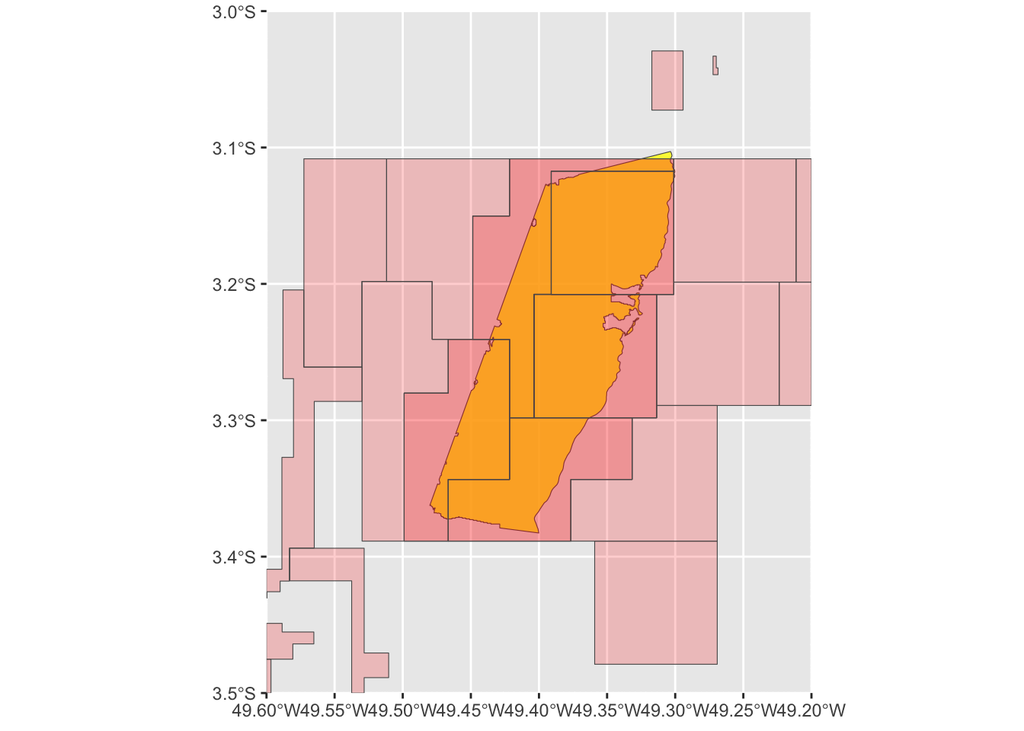

Figura 1: Projeto Maísa (amarelo) e áreas de mineração (vermelho)

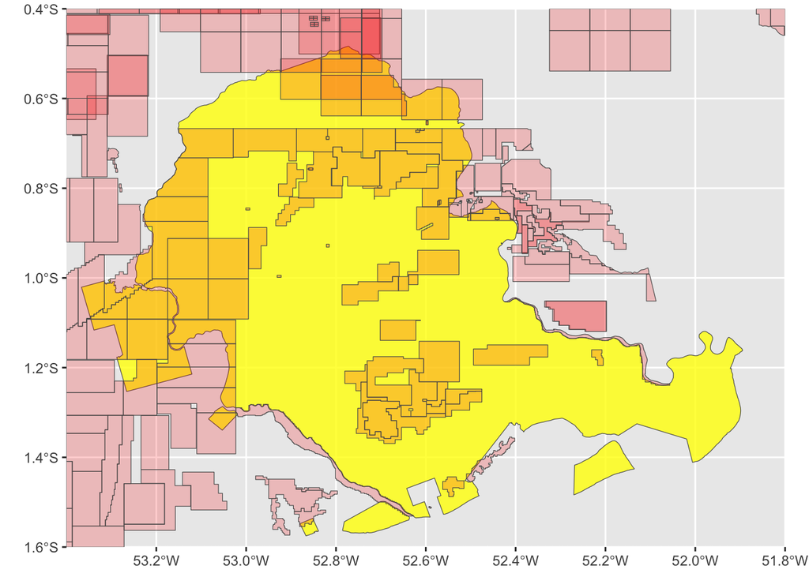

Figura 2: Projeto Jari/Pará (amarelo) e áreas de mineração (vermelho)

## Fase de requerimento

Por fase de requerimento, a maior parte se concentra nos processos com autorização de pesquisa (Tabela 8).

Tabela 8: Área de intersecção por fase de requerimento

| FASE | mineracao | area | pct |
| --- | --- | --- | --- |
| AUTORIZAÇÃO DE PESQUISA | 264 | 630 436.14 | 39.5% |
| REQUERIMENTO DE LAVRA GARIMPEIRA | 122 | 343 729.29 | 21.5% |
| REQUERIMENTO DE PESQUISA | 115 | 182 659.12 | 11.4% |
| APTO PARA DISPONIBILIDADE | 68 | 161 665.91 | 10.1% |
| DISPONIBILIDADE | 72 | 141 953.65 | 8.9% |
| CONCESSÃO DE LAVRA | 33 | 60 905.27 | 3.8% |
| REQUERIMENTO DE LAVRA | 41 | 60 801.79 | 3.8% |
| DIREITO DE REQUERER A LAVRA | 8 | 8 977.13 | 0.6% |
| LAVRA GARIMPEIRA | 2 | 3 648.67 | 0.2% |
| LICENCIAMENTO | 13 | 383.42 | 0.0% |
| REQUERIMENTO DE LICENCIAMENTO | 4 | 151.49 | 0.0% |
| REGISTRO DE EXTRAÇÃO | 2 | 5.20 | 0.0% |
| REQUERIMENTO DE REGISTRO DE EXTRAÇÃO | 1 | 4.45 | 0.0% |

## Status do projeto de carbono

Tabela 9: Área de intersecção por status do projeto

| status | projetos | area | pct_area |
| --- | --- | --- | --- |
| Registered | 14 | 637 315.0 | 40.5% |
| Withdrawn | 8 | 318 499.5 | 20.2% |
| On Hold | 5 | 136 221.8 | 8.7% |
| Under validation | 5 | 124 468.8 | 7.9% |
| Registration requested | 12 | 109 684.4 | 7.0% |
| Registration and verification approval requested | 9 | 93 890.5 | 6.0% |
| Rejected by Administrator | 1 | 70 331.7 | 4.5% |
| Registration requested denied | 1 | 44 062.4 | 2.8% |
| Inactive | 2 | 30 024.8 | 1.9% |
| Under development | 6 | 7 300.1 | 0.5% |
| Registration request denied | 1 | 1 483.0 | 0.1% |
| Retired | 3 | 120.4 | 0.0% |
| Validation | 2 | 7.2 | 0.0% |
| Certified | 4 | 3.7 | 0.0% |
| Suspended | 1 | 0.0 | 0.0% |

## Datas

- [68 projetos de carbono](https://docs.google.com/spreadsheets/d/1MClu8UinIoJNutZ0pt0YBkZ4W1Ni3h7hCsFjX_p99yg/edit?gid=1997971944#gid=1997971944) (93%) têm data posterior à área de mineração
- 208 (28%) [processos de mineração](https://docs.google.com/spreadsheets/d/1MClu8UinIoJNutZ0pt0YBkZ4W1Ni3h7hCsFjX_p99yg/edit?gid=986656238#gid=986656238) com intersecção de projetos de carbono foram instalados depois do início de projetos de carbono

## Áreas degradadas

- Dentre os 73 projetos identificados com alguma sobreposição com áreas de mineração, 37 apresentaram áreas degradadas em 2024, segundo dados do Imazon, sendo que em 28 dos projetos a área degradada é superior a 100 hectares (Tabela 10)
- No total, são 103 907 hectares degradados em áreas que em teoria deveriam ser preservadas, por estarem no período de vigência dos projetos

Tabela 10: Área degradada (ha) em projetos de carbono

| id_projeto | nome_projeto | area | area_projeto_hectares | pct |
| --- | --- | --- | --- | --- |
| 137 | Joao Bravo REDD+ Project | 35 134 | 328 421 | 10.7% |
| 139 | Juina REDD+ Project | 18 115 | 288 737 | 6.3% |
| 4142 | Serenity Valley REDD Project | 14 707 | 52 425 | 28.1% |
| 1118 | Suruí Forest Carbon Project | 8 650 | 247 802 | 3.5% |
| 1503 | RESEX Rio Preto-Jacundá REDD+ Project | 4 095 | 100 942 | 4.1% |
| 136 | Rio Catete REDD+ Project | 2 576 | 378 576 | 0.7% |
| 133 | Rio Curua REDD+ Project | 2 534 | 389 185 | 0.7% |
| 2558 | ABC Norte REDD Project | 2 511 | 145 777 | 1.7% |
| 3334 | Projeto Marajó REDD+ | 2 050 | 175 208 | 1.2% |
| 4681 | Ybyrá REDD+ Project | 1 952 | 76 397 | 2.6% |
| 1811 | Jari/Pará REDD+ Project | 1 773 | 908 550 | 0.2% |
| 3601 | CAAPII REDD+ PROJECT | 1 087 | 33 900 | 3.2% |
| 2508 | UNITOR REDD+ Project | 977 | 94 006 | 1.0% |
| 129 | Rio Crepori REDD+ Project | 939 | 397 631 | 0.2% |
| 2709 | Juruena River REDD+ Project | 840 | 48 952 | 1.7% |
| 3141 | Western Amazon | 754 | 91 706 | 0.8% |
| 832 | CIKEL BRAZILIAN AMAZON REDD APD PROJECT – AVOIDING PLANNED DEFORESTATION | 752 | 208 277 | 0.4% |
| 4042 | Cauaxi REDD+ Grouped Project | 635 | 58 779 | 1.1% |
| 2252 | Rio Anapu-Pacaja REDD Project | 555 | 164 967 | 0.3% |
| 144 | Rio Maicimirim REDD+ Project | 554 | 229 424 | 0.2% |
| 142 | Rio Presidente Medici REDD+ Project | 430 | 147 081 | 0.3% |
| 135 | Rio Bau REDD Project | 394 | 375 488 | 0.1% |
| 977 | RMDLT Portel-Para REDD Project | 387 | 194 534 | 0.2% |
| 1571 | Projeto REDD+ Manoa | 387 | 73 149 | 0.5% |
| 131 | Rio Teles Pires REDD+ Project | 340 | 392 176 | 0.1% |
| 2482 | Boa Fé REDD Project | 207 | 433 516 | 0.0% |
| 125 | Ipixuna REDD+ Project | 177 | 210 023 | 0.1% |
| 4886 | Projeto REDD+ TATUY | 172 | 22 740 | 0.8% |
| 4850 | Amazonas APD Grouped Project | 59 | 26 061 | 0.2% |
| 1654 | Fortaleza Ituxi REDD Project | 57 | 46 592 | 0.1% |
| 4265 | REDD+ Café Apuí Agroflorestal (CAA) | 34 | 3 707 | 0.9% |
| 1115 | Jari/Amapá REDD+ Project | 30 | 66 126 | 0.0% |
| 1953 | The ARC REDD+ Project | 25 | 53 293 | 0.0% |
| 3152 | Alto Xingu Grouped REDD+ Project | 11 | 18 439 | 0.1% |
| 4034 | Agropalma REDD+ Project | 5 | 51 922 | 0.0% |
| 4542 | Amazônidas REDD+ AUDD Grouped Project | 4 | 265 085 | 0.0% |
| 1329 | Maísa REDD+ Project | 3 | 30 017 | 0.0% |